# 002-Basic_Python

```python
# "Magic" to allow plotting and math automatically below.
# Don't forget to execute this cell!
%pylab inline
```

`numpy` allows math, `matplotlib` allows plotting.

## Symbols are the building blocks

|  | Mathematical Expression | Python Expression |
| --- | --- | --- |
| Numbers | $2$, $2,000$, $2\times10^9$ | `2`, `2000`, **`2e9`** |
| Operators | $a + b$ | `a + b` |
|  | $a - b$ | `a - b` |
|  | $a \times b$ | **`a * b`** |
|  | $\frac{a}{b}$ | **`a / b`** |
|  | $a^b$ | `a ** b` |
| Parentheses | $2(a+b)$ | `2*(a+b)` |
| Variables | $a$, $b$, $\alpha$, $\beta$ | `a`, `b`, `alpha`, `beta` |
| Functions | $f_1(x)$ | `f1(x)` |

## Basic Math

You can do arithmetic with Python

### Use Python as calculator:

```python
print (3+2)
print (2**3)
print (3/5)
print ( (3+5)-(2-1))
```

```
5
8
0.6
7
```

```python
(1 + 2) * (34 - 2) / 10
```

```
9.6
```

```python
10000 / (3 * 8 * 30)
```

```
13.88888888888889
```

Exponentiation is done with `**`

```python
2**3
```

```
8
```

```python
2**0.5
```

```
1.4142135623730951
```

Not very exciting, not really coding; Writing code requires abstraction, so that code can be reused in different circumstances

### Challenge

If I had to walk 10000 miles, and I could walk 3 miles an hour for 8 hours a day, how many months would it take me?

## Variables

Variables are placeholders for data; Variables can hold a different value at different executions of the code.

```python
x = 2
y = 3
my_num = 99
my_string = "luft ballons" # A "string" is a piece of text
```

You can print out the *value* of a *variable*

```python
print(x)
print(my_string)
print (my_num, my_string)
```

```
2
luft ballons
99 luft ballons
```

Variables can be reassigned.

```python
x = 2
print(x)
x = 3
print(x)
```

```
2
3
```

Note that the equals sign (`=`) is an *assignment* operator: it says "I want to call the thing on the right by the name on the left"

What else can we do with variables? Variables can be used to manipulate data

```python
x + y
```

```
6
```

```python
z = x + y
print (z)
```

```
6
```

Note: When you write x=7 you are making a *statement*. When you operate on your variables you are writing *expressions*. ipython notebook evaluates each expression and then prints that on the screen. But that is not typical Python code behavior.

We use variables when we don't know ahead of time the value of something. This is almost always the case when we write code. Variables allow us to make code general and applicable to many different situations. When we use a variable in our program we say to the computer: when this program executes, this variable x will have some value, (the value may depend on user input or on a measurement of the temperature or on the values of other variables in the program). I don't know what that value will be, but whater it is do the following.

## Functions

Functions are pieces of code that you can reuse by *calling* them

```python
def addtwo(myVar):
    print(myVar+2)
```

myVar is the name of the parameter that you *pass* to the function. When you *call* that function, you can pass any (numeric) value to the function and it will be stored in the name myVar within the function. Note: myVar is only defined within this function

Note: myVar is only defined within this function

```python
print(myVar)
```

```
---------------------------------------------------------------------------
NameError                                 Traceback (most recent call last)
<ipython-input-13-11d180c4804a> in <module>()
----> 1 print(myVar)

NameError: name 'myVar' is not defined
```

```python
addtwo(5)
```

```
7
```

### Challenge:

write a function which takes in two parameters and prints their sum to the screen. Now call this function, passing necessary parameters and check that it works.

Great! We can write functions that do things! But how would you save the result of a computation (ie output of a function) for future use in your code? try:

```python
y = addtwo(2)
print(y)
```

```
4
None
```

### 'Return'

Functions can 'return' a value

```python
def addtwo(myVar):
    return (myVar+2)
```

what do you think the following 2 expressions will produce?

```python
y = addtwo(5)
print(y)
```

```
7
```

```python
y = addtwo(x)
print(y)
```

```
5
```

```python
y = addtwo(x)/2
print (y)
y = addtwo( addtwo(x)/2)
print(y)
```

```
2.5
4.5
```

## Python built-in functions:

Now that we know what functions are, we can understand better some of the things we have already done: eg: print() is a function that is part of an included library (of functions) in Python

Other functions

```python
cos(x)
```

```
-0.98999249660044542
```

```python
cos(2*pi*x)
```

```
1.0
```

```python
floor(2.56)
```

```
2.0
```

```python
sqrt(addtwo(floor(cos(x))))
```

```
1.0
```

### Function challenge

- write a function called remainder that returns the remainder of x/y
- a function that prints the quotient and returns the remainder

## Functions on lists:

We saw functions last class when we made our plot:

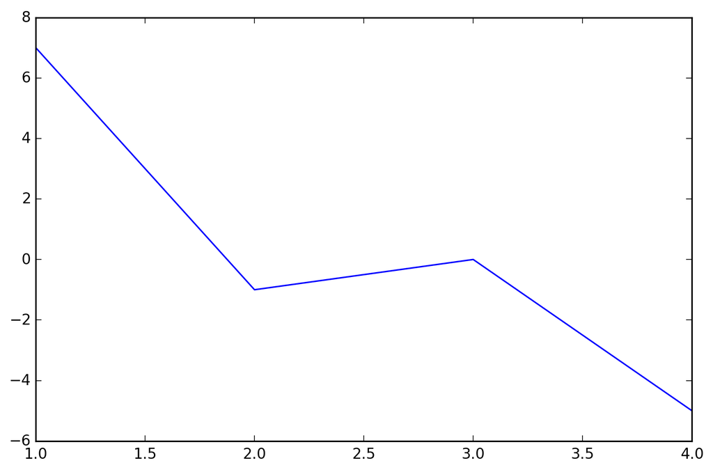

```python
plot ([1,2,3,4], [7,-1,0,-5])
```

From homework:

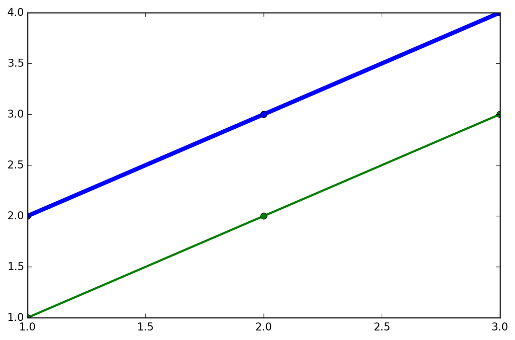

```python
plot([1,2,3], [1,2,3], 'go-', label='line 1', linewidth=2)
plot([1,2,3], [2, 3, 4], 'bo-', label='line 2', linewidth=2)

plot([1,2,3], [2, 3, 4], color='b', marker='o', label='line 2', linewidth=4)
```

plot() is a function that takes in several variables. There are a few differences from what we've done so far:

- variables are of different type than just simple scalars; ie [1,2,3] => these are LISTS (or arrays)
- the arguments after the 1st two are optional and specified by name. These are called keyword arguments. They are confusing, we'll talk about then later. For now, just learn to use them in plot()

## Lists

Lists are create with square brackets

```python
myList = [1, 2]
myList
```

```
[1, 2]
```

```python
print(myList)
```

```
[1, 2]
```

Functions that are specific to Lists and operate on lists (called *methods*) sometimes require the list.function() syntax. We will learn about this more when we study objects and object oriented programming. But for now:

```python
l = []
l.append(1)
l.append(2)
l
```

```
[1, 2]
```

```python
nameList=["yongsun", 'janet', 'aleksandra', 'tayshana']
print (nameList)
nameList.append("Laura")
print (nameList)
```

```
['yongsun', 'janet', 'aleksandra', 'tayshana']
['yongsun', 'janet', 'aleksandra', 'tayshana', 'Laura']
```

```python
nameList[3] #returns the 3 rd element from the list
```

```
'tayshana'
```

is this what you expected? write an expression using our nameList that returns "youngsun"

```python
nameList[0]
```

```
'yongsun'
```

Does the list still include tayshana or has it been removed? Try it out. Raise your hand if you think Tayshana is still in the list.

```python
nameList.remove('tayshana')
nameList
```

```
['yongsun', 'janet', 'aleksandra', 'Laura']
```

More list functions: https://docs.python.org/2/tutorial/datastructures.html

### Plotting with Lists again (review)

In Python, the `plot` function takes two lists as *arguments*: a list of `x`-coordinates, and a list of `y`-coordinates. That is the bare minimum you need to plot.

### Practice

Write code to plot [0, 1,2,3] vs [0,2,1,3]

You can add keyword arguments to change the appearance of a plot. You can plot multiple data sets on the same plot.

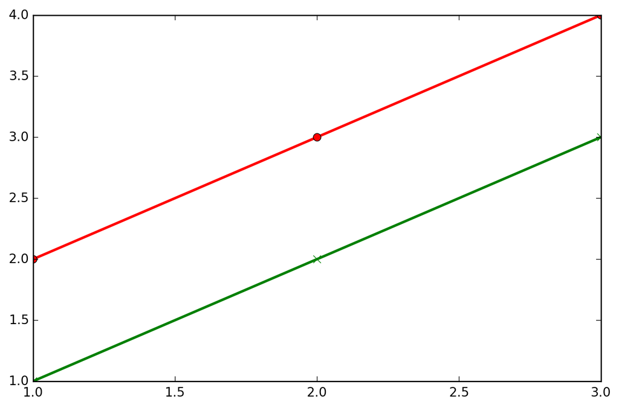

```python
xList = [1,2,3]
yList1 = [1,2,3]
yList2 = [2,3,4]
plot(xList, yList1, 'gx-', label='line 1', linewidth=2)
plot(xList, yList2, 'ro-', label='line 2', linewidth=2)
```

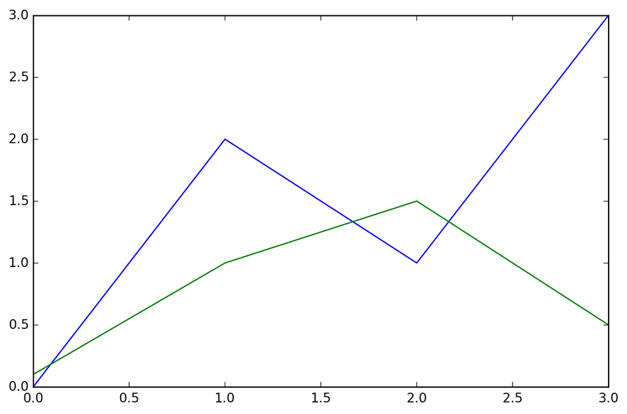

```python
xs = [0, 1, 2, 3]
ys = [0, 2, 1, 3]
plot(xs, ys)

ys2 = [0.1, 1, 1.5, 0.5]
plot(xs, ys2)
```

## Arrays

An *array* is a like a *list*, but for just numbers. It allows you to do math on the whole array.

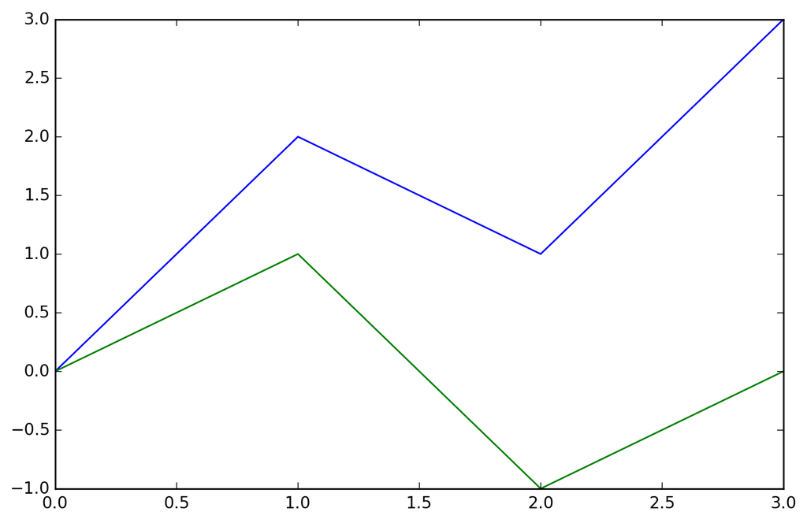

```python
xs = array([0, 1, 2, 3])
ys = array([0, 2, 1, 3])
plot(xs, ys)

ys2 = ys - xs
plot(xs, ys2)
```

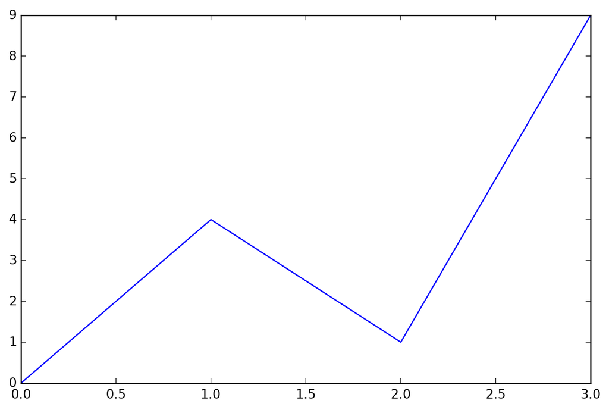

```python
xs = array([0, 1, 2, 3])
ys = array([0, 2, 1, 3])
plot(xs, ys**2)
```

### Creating arrays

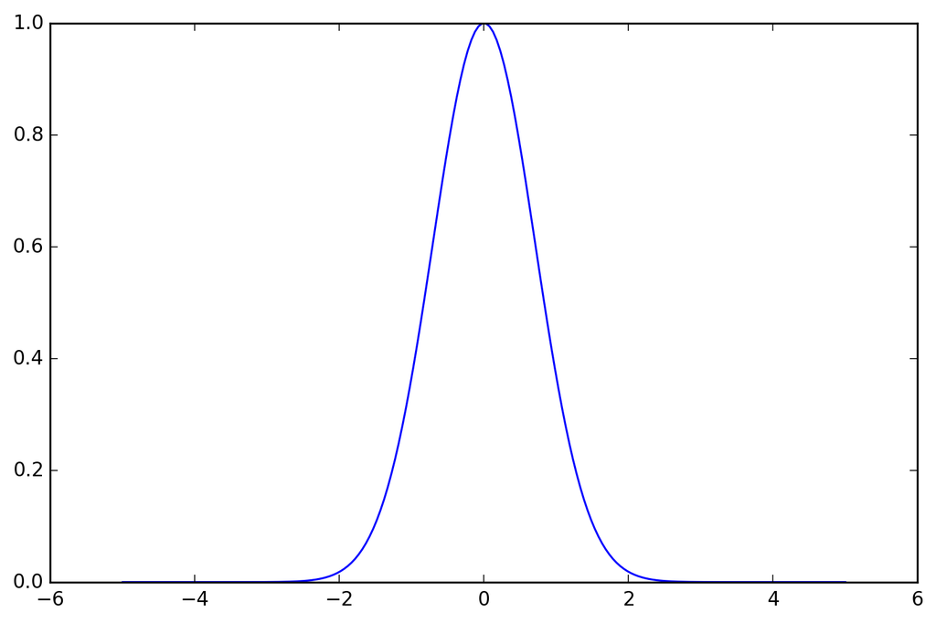

```python
xs = linspace(-5, 5, 200) # Create an array from -5 to 5, with 200 elements
ys = exp(-xs**2)
plot(xs, ys)
```

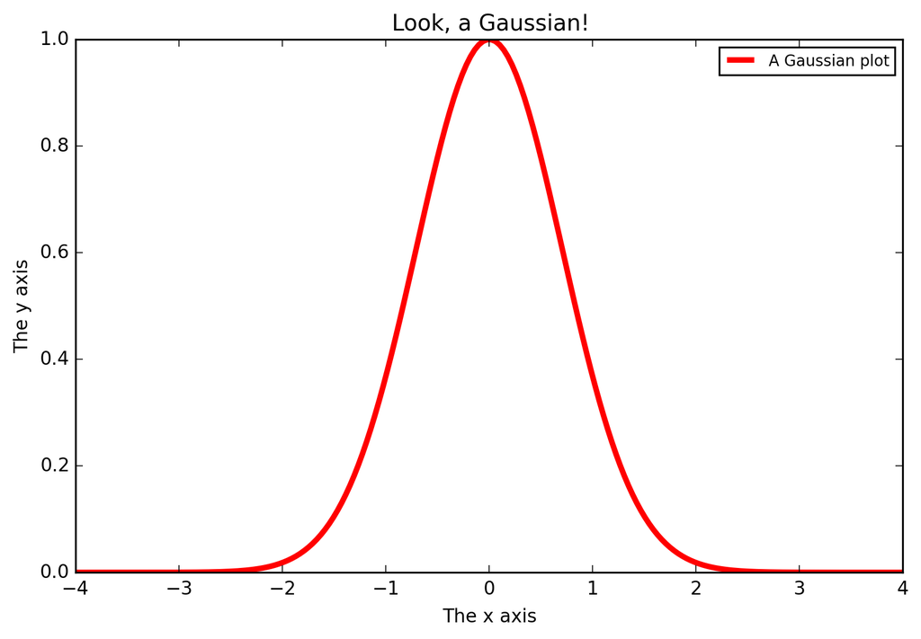

```python
xs = linspace(-4, 4, 200) # Create an array from -4 to 4, with 200 elements
ys = exp(-xs**2)
plot(xs, ys, label="A Gaussian plot", linewidth=3, color='r')
title("Look, a Gaussian!")
xlabel("The x axis")
ylabel("The y axis")
legend() # Uses the labels from each plot expression
```

functions operating on arrays:

```python
sum(xs)
```

```
2.8421709430404007e-14
```

### Subarrays

```python
z = xs[0:10]
```

How many elements does z have?

```python
print(z)
```

```
[-4.         -3.95979899 -3.91959799 -3.87939698 -3.83919598 -3.79899497
 -3.75879397 -3.71859296 -3.67839196 -3.63819095]
```

```python
print (len(z))
```

```
10
```

### 2D arrays

```python
mat = array([[1,2,3],[10,11,12]])
print(mat)
```

```
[[ 1  2  3]
 [10 11 12]]
```

```python
myRow = mat[0, :]
print(myRow)
```

```
[1 2 3]
```

Now write code to print the 2nd column

```python
myCol = mat[:, 1]
print(myCol)
```

```
[ 2 11]
```

```python
im = loadtxt(fname='data/sizeCalibration.txt')
```

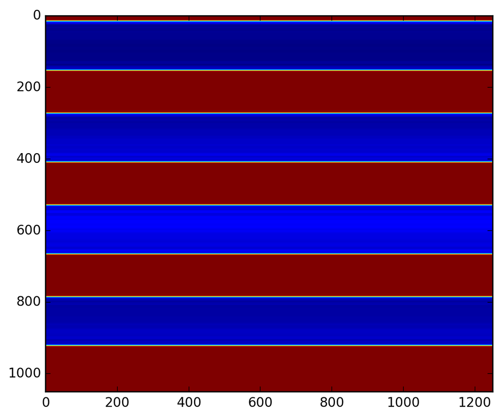

```python
imshow(im)
```

```python
slice = im[:,1];
print(len(slice))
```

```
1050
```

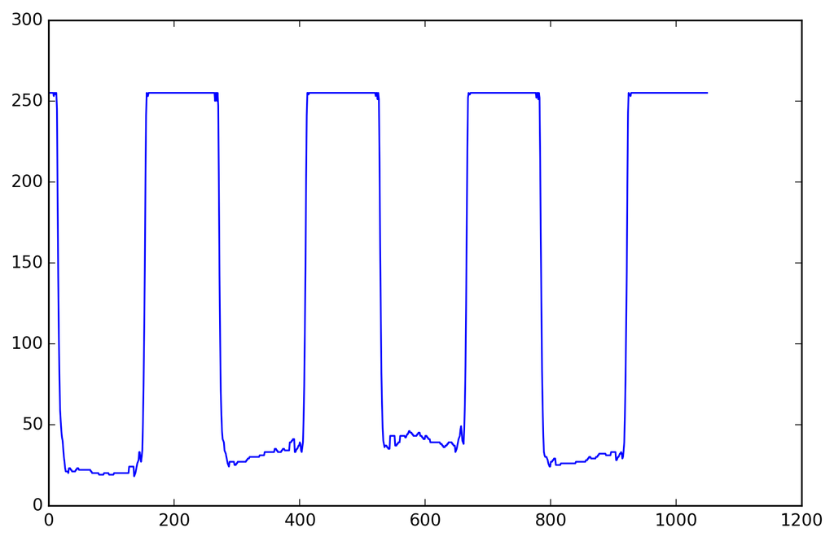

```python
plot(range(0,1050), slice)
```

```python
print(max(slice))
print (min(slice))
```

```
255.0
18.0
```